# Reusable To-Go with OZZI

- Show All Code
- Hide All Code
- View Source

A conjoint analysis of OZZI reusable containers in university dining

Author

Sai Lekhana Kottiyada, Sri Murari Dachepalli, Jyothika Priyanka Talluri, Ulindala Venkata Nikhil Kumar Reddy

Published

December 7, 2025

# Abstract

Our project studies the OZZI reusable container system used at George Washington University to reduce dining waste by replacing single-use to-go boxes. Students exchange a token for a container, return it through a scanning bin, and reuse the system repeatedly—creating a closed-loop, low-waste alternative to disposables.

Its competitors are biodegradable and single-use plastic containers, OZZI offers a more effective sustainability solution. Biodegradable containers still generate large volumes of waste and often end up in landfills, while plastics persist for decades. A single OZZI container, however, can be reused many times, significantly lowering environmental impact.

The key attributes we analyzed are deposit amount, return location, box durability, and refund policy to understand what drives student adoption.

Results showed strong preferences for a refundable $5 deposit, campus-wide return bins, and 100 wash cycles, while high deposits and non-refundable policies reduced interest.

[figure not shown]

# Introduction

OZZI is a sustainable packaging company providing reusable container systems that replace single-use plastics in dining operations. At GW, students participate in the OZZI program by paying a $5 refundable deposit, exchanging a token for a container, and returning it through a receptacle bin. The goal is to reduce landfill waste while maintaining convenience for users.

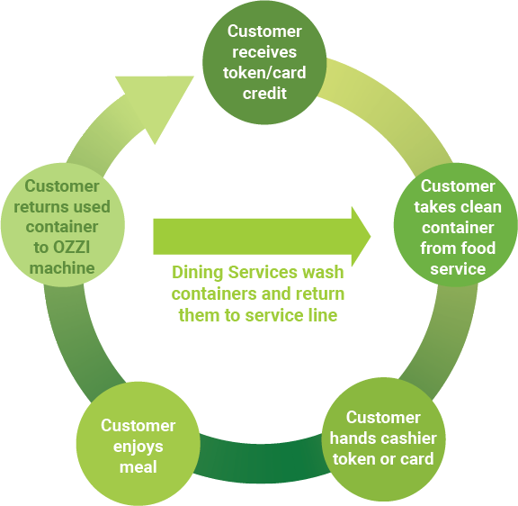

Disposable containers currently serve as the main competitor to OZZI on campus. They require no deposit or return but create more waste and higher long-term costs. This project aims to identify which product attributes that drive students to choose OZZI over disposable alternatives.

# Survey Design

- Eligibility Requirements: To ensure relevance, only students were included. Screening questions used were:
  - “Are you a current a student?” (Yes/No)
  - “What do you know about reusable containers”

Only those who confirmed student status continued to the survey. This ensured responses reflected the preferences of individuals who regularly interact with campus dining and would realistically encounter the OZZI system.

- We collected demographic and behavioral data including:
  - Year in school (Undergraduate/Graduate)
  - Frequency of dining hall usage (Daily / Weekly / Occasionally)
  - Prior experience with OZZI (Yes/No)
- Educational Material: Before answering the choice questions, respondents viewed a short educational page that explained how the OZZI reusable container program works. This page described the purpose of the containers, how students return used containers, how the deposit and refund process functions, and what wash cycles represent. The goal of this section was to make sure all respondents understood the meaning of each attribute in the conjoint tasks, especially since many students had little or no prior experience with OZZI.
- Decision Variables: The decision variables represent the key design features of the OZZI reusable container system that may be adjusted to improve adoption and usability. These variables correspond directly to the product attributes included in our conjoint analysis, as they influence convenience, perceived risk, and overall student preferences. The decision variables and ranges considered for this project include:

Attributes and Levels Included in the Conjoint Survey

| Attribute | Levels | Description |
| --- | --- | --- |
| Deposit Amount | $5, $10 | Determines the upfront cost and affects perceived risk. |
| Return Location | Dining Halls, Halls & Dorms, Campus-wide | Influences convenience and likelihood of consistent participation. |
| Wash Cycles | 50, 75, 100 cycles | Represents container durability and sustainability performance. |
| Refund Policy | Refundable, Non-refundable, Free-loss | Affects perceived responsibility and financial risk. |
| No-choice Option | Disposable container | Opt-out option representing the current baseline on campus. |

These decision variables will guide recommendations for optimizing the OZZI system design, balancing operational feasibility with user preferences to increase overall adoption of reusable containers on campus.

- Choice Questions: Respondents evaluated three alternatives per choice question, two OZZI container options (with varying deposit, return, wash, and refund attributes) and Disposable container as the baseline.  
  The Disposable option represented the current default on campus, serving as a realistic alternative for students who choose not to use OZZI. Each respondent completed six randomized choice tasks to capture preferences across different OZZI configurations.

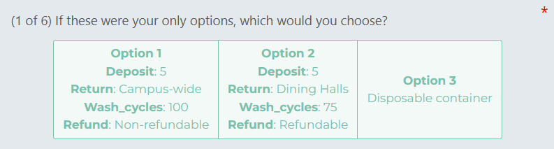

- Changes in Survey: Between the pilot and final survey, several refinements were made to improve clarity and reach. Variable names were updated to use underscores instead of spaces to ensure consistent formatting for analysis. The educational page was expanded to include more information about OZZI, the return-bin locations, and how the system works in practice. Finally, while the pilot survey was restricted to students at George Washington University, the final survey was opened to all students in the United States.

# Data Analysis

### Sample Description

The data includes students across multiple years, dining hall usage patterns, and sustainability. Around 10% of the respondents reported previously using OZZI, indicating that most students took the survey without any prior experience.

OZZI Preference among students

| Category | Count |
| --- | --- |
| no | 229 |
| yes | 20 |

Hall Frequency

| Category | Count |
| --- | --- |
| 1_2_week | 47 |
| 3_4_week | 50 |
| daily | 22 |
| lt1_week | 49 |
| never | 80 |

Study Year/ Class

| Category | Count |
| --- | --- |
| freshman | 25 |
| grad | 46 |
| junior | 66 |
| other | 4 |
| senior | 58 |
| sophomore | 49 |

Waste Importance

| Category | Count |
| --- | --- |
| 1 | 5 |
| 2 | 18 |
| 3 | 48 |
| 4 | 84 |
| 5 | 94 |

Container Preference

| Category | Count |
| --- | --- |
| compostable | 61 |
| other | 34 |
| ozzi | 86 |
| plastic | 67 |

### Data Cleaning

The raw survey data was cleaned to ensure only complete and reliable responses were included. We removed any responses that contained missing values (NA’s) in the survey questions, meaning at least one mandatory question was left unanswered. The time zone was changed from UTC to EST, and total completion time was calculated in minutes. We filtered out responses where participants selected the same option for all choice tasks, as well as those who completed the entire survey in less than 1 minute, indicating low engagement.

### Modelling

To understand what drives students decisions between reusable OZZI containers and disposable options, we estimated three different choice models. First, we fit a standard multinomial logit (MNL) model to measure the average effect of each attribute. Next, we estimated a mixed logit model to see how these preferences vary across students. Finally, we ran a subgroup model splitting respondents by dining hall usage frequency.

The utility for each choice alternative was modeled as:
$$\begin{aligned}
u_{j} =\;&
\beta_{\text{deposit}} * x_j^{\text{deposit}} +
\beta_{\text{wash}} * x_j^{\text{washcycles}} +
\beta_{\text{dininghalls}} * \delta_j^{\text{dininghalls}} +
\beta_{\text{campuswide}} * \delta_j^{\text{campuswide}} \\
&+
\beta_{\text{freeloss}} * \delta_j^{\text{freeloss}} +
\beta_{\text{nonrefundable}} * \delta_j^{\text{nonrefundable}} +
\beta_{\text{nochoice}} * \delta_j^{\text{nochoice}} +
\epsilon_{j}
\end{aligned}$$

#### Model Results

##### Simple Logit Model

**Baseline MNL Coefficients**

| Attribute / Level | Estimate | Std. Error | z-value | p-value |
| --- | --- | --- | --- | --- |
| Deposit | -0.04505 | 0.03034 | -1.485 | 0.1376 |
| Wash Cycles | 0.01394 | 0.00563 | 2.477 | 0.0133* |
| Return: Campus-wide | 0.28748 | 0.15305 | 1.878 | 0.0603 |
| Return: Dining Halls | -0.14270 | 0.13864 | -1.029 | 0.3033 |
| Refund: FreeLoss | -0.56157 | 0.14740 | -3.810 | <0.001*** |
| Refund: Non-refundable | -1.86512 | 0.14572 | -12.799 | <0.0001*** |
| No Choice. | -1.93029 | 0.28971 | -6.663 | <0.0001*** |

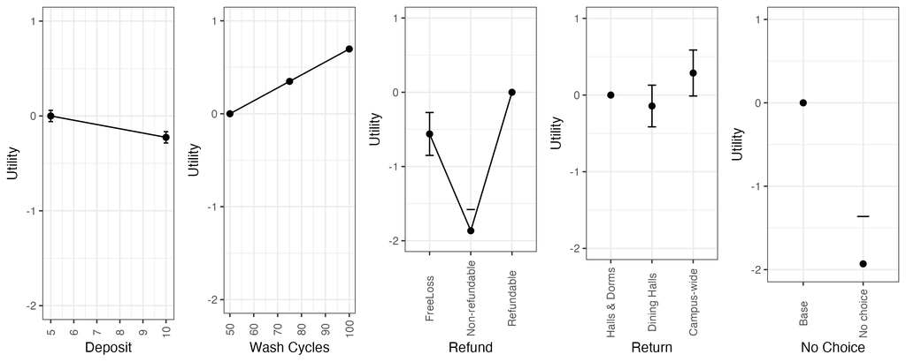

##### Mixed Logit Model

**Mixed Logit Mean Coefficients**

| Attribute / Level | Mean Estimate | Std. Error | z-value | p-value |
| --- | --- | --- | --- | --- |
| Deposit | -0.08926 | 0.07375 | -1.210 | 0.2262 |
| Wash Cycles | 0.01491 | 0.02074 | 0.719 | 0.4721 |
| Return: Campus-wide | 0.44748 | 0.23584 | 1.897 | 0.0578 |
| Return: Dining Halls | -0.36921 | 0.22901 | -1.612 | 0.1069 |
| Refund: FreeLoss | -0.81704 | 0.27991 | -2.919 | 0.0035** |
| Refund: Non-refundable | -3.35021 | 1.02991 | -3.253 | 0.0011** |
| Opt-out (No Choice) | -3.15237 | 1.17480 | -2.683 | 0.0073** |

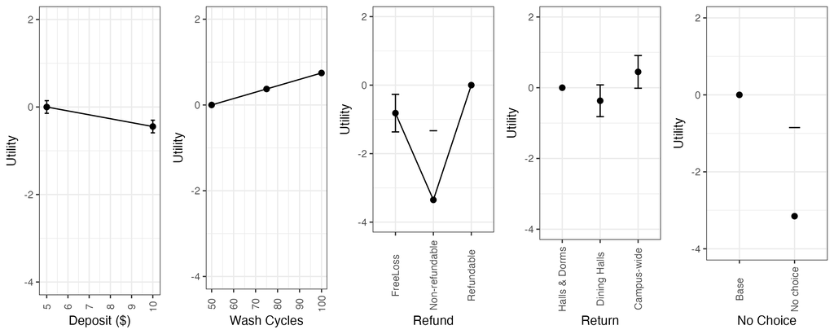

**Mixed Logit SD Coefficients**

[output not shown]

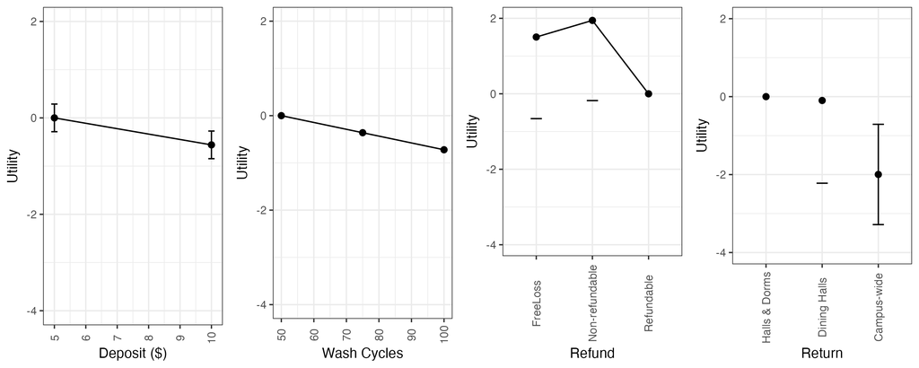

##### Sub Group Analysis

**Subgroup Model Coefficients**

| Attribute / Level | Estimate | Std. Error | z-value | p-value |
| --- | --- | --- | --- | --- |
| Deposit | -0.04505 | 0.03034 | -1.485 | 0.1376 |
| Wash Cycles | 0.01394 | 0.00563 | 2.477 | 0.0133* |
| Return: Campus-wide | 0.28748 | 0.15305 | 1.878 | 0.0603 |
| Return: Dining Halls | -0.14270 | 0.13864 | -1.029 | 0.3033 |
| Refund: FreeLoss | -0.56157 | 0.14740 | -3.810 | <0.001*** |
| Refund: Non-refundable | -1.86512 | 0.14572 | -12.799 | <0.0001*** |
| No Choice | -1.93029 | 0.28971 | -6.663 | <0.0001*** |
| Deposit_B | -0.02595 | 0.04099 | -0.633 | 0.5267 |
| Wash Cycles_B | -0.00350 | 0.00620 | -0.564 | 0.5724 |
| Return: Campus-wide_B | 0.14259 | 0.22325 | 0.639 | 0.5230 |
| Return: Dining Halls_B | 0.07684 | 0.20188 | 0.381 | 0.7035 |
| Refund: FreeLoss_B | 0.00662 | 0.20239 | 0.033 | 0.9739 |
| Refund: Nonref_B | -0.18342 | 0.21299 | -0.861 | 0.3892 |

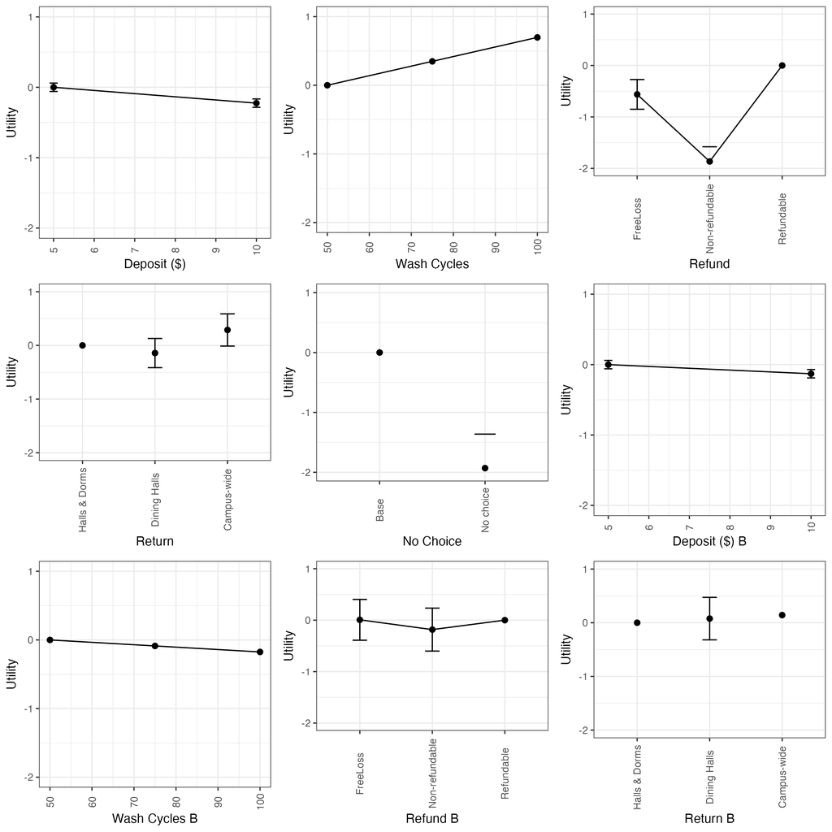

#### Interpretation

Wash Cycles: Wash Cycles has a positive and significant effect (0.014, p < 0.05). Students value containers that last longer, suggesting durability is an important attribute when evaluating reusable systems.

Refund Policy: Both refund attributes show strong effects. Non-refundable refunds have a large negative coefficient (–1.87, p < 0.001), meaning students strongly reject options that involve financial risk. Free Loss (–0.56, p < 0.001) is also disliked but much less so than non-refundable.

Return Location: Campus-wide return bins (0.29) are preferred over the baseline (Halls & Dorms), although the effect is only marginally significant. Dining Halls return locations (–0.14) are slightly less preferred. This indicates students value flexibility and convenience in where they can drop off containers.

No Choice: Negative coefficient (–1.93) shows most students prefer to pick one of the container options rather than “Disposable Container”

In summary, students favor lower deposits, refundable options, and campus-wide returns. These results suggest that increasing convenience and lowering perceived financial risk could help improve participation in the OZZI program.

# Results

### Willingness To Pay

We estimated the model in willingness to pay space using Deposit as the scale parameter. Students place a positive value on durability. The willingness to pay for Wash Cycles is 0.21, which means students accept a higher deposit for containers that last longer. Campus-wide return bins have a willingness to pay of 6.22. Students value having return locations across campus. The Dining Halls option is not statistically significant. Refund policies show the strongest effects. The willingness to pay for the Free Loss policy is -9.84. The willingness to pay for the Non-refundable policy is -34.18. Students clearly prefer refundable deposits.

**WTP Estimates**

| Attribute | Estimate | Standard Error | p-value |
| --- | --- | --- | --- |
| Wash Cycles | 0.2116 | 0.0915 | 0.0207 |
| Return: Campus-wide | 6.2186 | 2.6258 | 0.0179 |
| Return: Dining Halls | -1.8715 | 1.9425 | 0.3353 |
| Refund: Free Loss | -9.8388 | 3.8632 | 0.0109 |
| Refund: Non-refundable | -34.1773 | 12.9457 | 0.0083 |
| No Choice | -33.6708 | 12.1129 | 0.0054 |

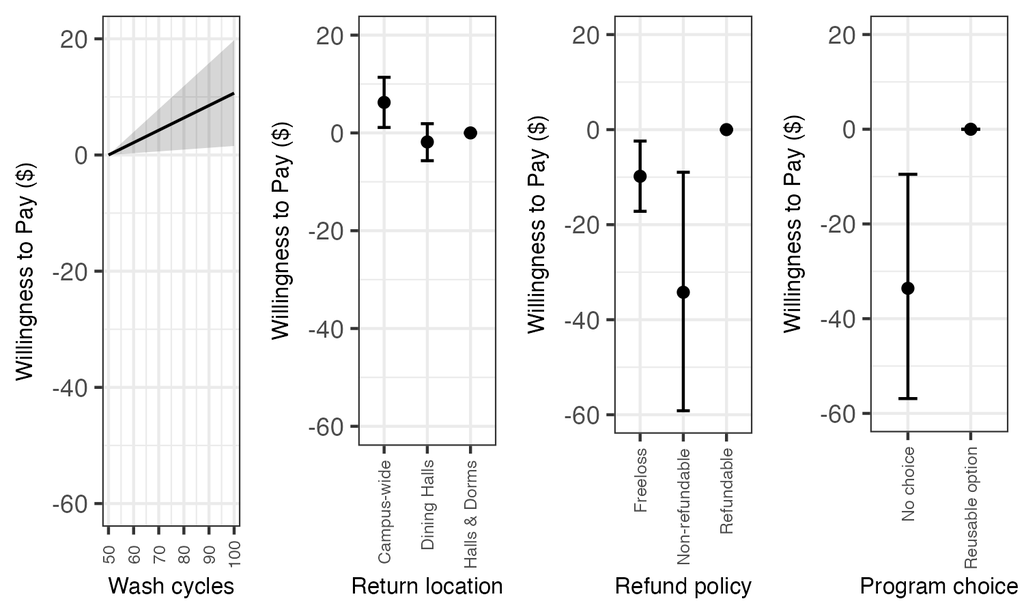

Overall, the willingness to pay results show that students value durability, refundable deposits and convenient return locations. Students strongly avoid policies that increase financial risk.

### Market Share Simulation

We ran two market simulations to compare two reusable container designs against the disposable option. Alternative 1 uses the strongest combination of attributes from the model results. Alternative 2 represents another possible design. Alternative 3 is the disposable option. In the second simulation we compared a random combination of attributes for Alternative 2 against the best design from the model.

**Scenario 1**

| Attribute | Alt 1 | Alt 2 | Alt 3 (Disposable) |
| --- | --- | --- | --- |
| Deposit | 5 | 5 | 0 |
| Wash Cycles | 100 | 100 | 0 |
| Return Location | Campus-wide | Campus-wide | None |
| Refund Policy | Refundable | Free Loss | Not applicable |
| No Choice Indicator | 0 | 0 | 1 |

**Scenario 2**

| Attribute | Alt 1 | Alt 2 | Alt 3 (Disposable) |
| --- | --- | --- | --- |
| Deposit | 5 | 10 | 0 |
| Wash Cycles | 100 | 75 | 0 |
| Return Location | Campus-wide | Dining Halls | None |
| Refund Policy | Refundable | Refundable | Not applicable |
| No Choice Indicator | 0 | 0 | 1 |

**Simulated Market Shares**

| Scenario | Alt | Market Share | Lower CI | Upper CI |
| --- | --- | --- | --- | --- |
| 1 | 1 | 0.621 | 0.571 | 0.667 |
| 1 | 2 | 0.354 | 0.308 | 0.403 |
| 1 | 3 | 0.025 | 0.016 | 0.039 |
| 2 | 1 | 0.495 | 0.424 | 0.566 |
| 2 | 2 | 0.452 | 0.383 | 0.522 |
| 2 | 3 | 0.053 | 0.042 | 0.065 |

For Scenario 1, Alternative 1 reaches a share of 62%. This result matches the model results because Alternative 1 uses the most preferred combination with low deposit, high durability, refundable deposit, and campus-wide returns. Alternative 2 performs worse, with a share of 35%. The Free Loss refund reduces its appeal. The disposable option has very low share.  
For Scenario 2, Alternative 1 remains the top choice but drops to 50%. This occurs because Alternative 2 becomes more competitive when its attributes change and it increases to 45%.

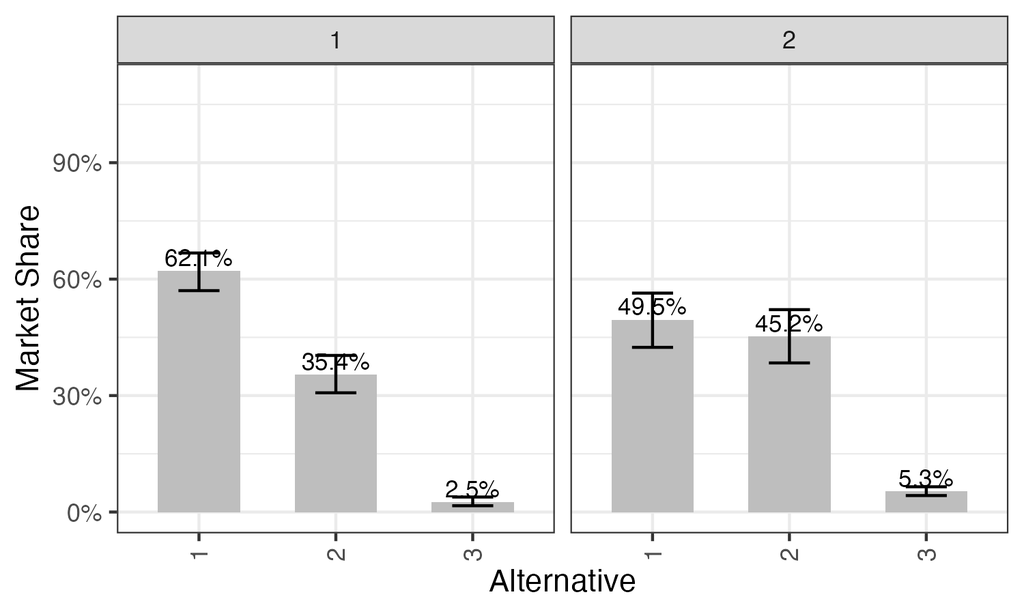

### Sensitivity Analysis

We tested how demand for the reusable option changes when we vary the deposit and key attributes. When the deposit increases from 1 to 15 dollars, predicted market share declines steadily from 0.67 (95 percent interval 0.60 to 0.73) to 0.48 (0.38 to 0.58). Within the range used in the survey (5 to 10 dollars), share falls from about 0.62 to 0.55, showing that higher deposits reduce participation but still raise expected revenue per user.

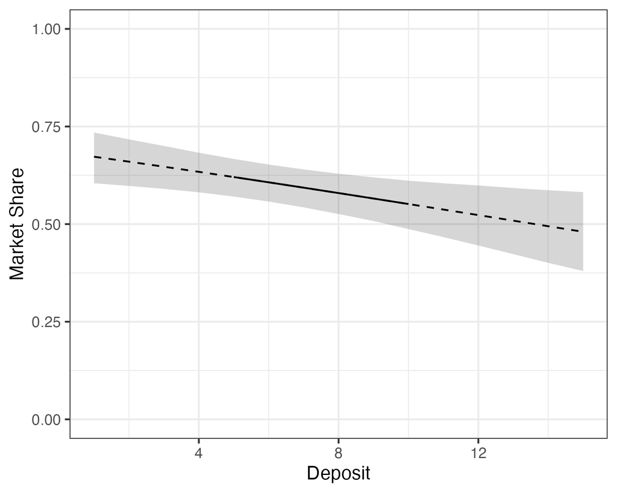

The tornado plot shows how sensitive demand is to small changes in deposit and wash cycles. Lowering the deposit to 2.50 dollars raises the predicted share to 0.65, and increasing it to 7.50 dollars lowers it to 0.59. Changes in wash cycles have larger effects. Increasing wash cycles from 100 to 120 raises share to 0.68, while reducing them to 40 lowers share to 0.44. This suggests that durability plays a bigger role than small price changes.

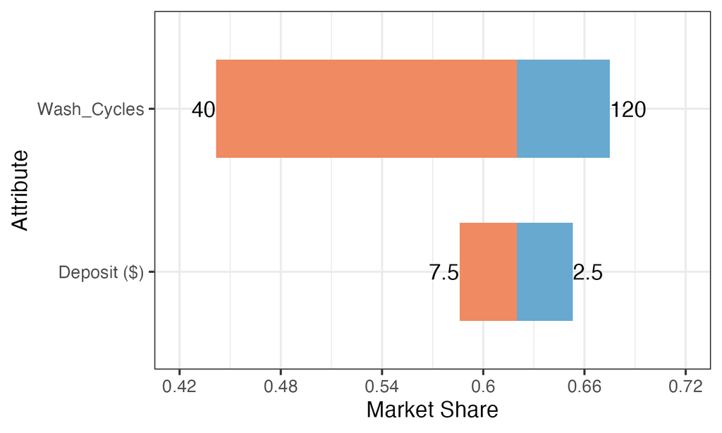

Overall, demand is most sensitive to wash-cycle durability. Deposits in the 5 to 10 dollar range remain competitive, while maintaining high durability helps keep participation strong despite price changes.

One of the limitation for the analysis can be that most respondents have never used OZZI. Because of this, many choices were made without real experience using a reusable container system. Stated preferences may not fully match actual behavior once students interact with the program.

# Final Recommendations and Conclusions

Our results show that the OZZI reusable container can be competitive when designed with a low deposit, convenient return access, and a refundable policy. In the main simulation, the best design achieved a predicted market share of about sixty percent, much higher than the disposable option. Price sensitivity results suggest that a five-dollar deposit is the most effective point for maintaining strong adoption.

Key opportunities for increasing demand include offering campus-wide return locations, keeping the deposit low, and using policies that reduce financial risk. The main uncertainty is that most students have never used OZZI, so real behavior may differ from stated choices. Even with this limitation, the results point toward a clear strategy: low cost and high convenience drive the greatest participation.

# Limitations

This study only includes students, so the results may not reflect the preferences of staff, faculty, or visitors. These groups also use to-go containers on campus, and some stores already offer OZZI, so expanding to these users would give a more complete picture of demand. Another limitation is that most respondents had no prior experience with OZZI. Their choices are based on expectations rather than real use, which may lead to different behavior once a deposit, return process, and daily routines come into play.

The most valuable information to collect next would be usage data from a real pilot, including how often people return containers, how deposits affect participation, and what barriers students and staff face. The most important unknowns that could affect our findings are how people behave once they use the system regularly and how convenience of return locations works in practice. Understanding these points would help improve future decisions about system design and pricing.

# Reusable To-Go with OZZI

Welcome! We are graduate students at George Washington University studying preferences for reusable to-go containers.

This short survey (just 4–5 minutes) asks for your thoughts on different container program options.

You don’t need to be from GW to participate, students from any college or university are welcome!

Your responses are completely anonymous and for academic research only. Thanks for helping us explore how to make campus dining more sustainable!

[figure not shown]

```r
sd_next()
```

# Consent

Participation is voluntary and anonymous. You must be 18+ and a current student to participate.

You may exit at any time without penalty - no pressure.  
If you would like to continue, please answer the following questions below.

```r
sd_question(
  type  = 'mc',
  id    = 'consent_age',
  label = "I am age 18 or older",
  option = c(
    'Yes' = 'yes',
    'No'  = 'no'
  )
)
```

I am age 18 or older

Yes

No

```r
sd_question(
  type  = 'mc',
  id    = 'consent_understand',
  label = "I have read and understand the above information",
  option = c(
    'Yes' = 'yes',
    'No'  = 'no'
  )
)
```

I have read and understand the above information

Yes

No

```r
sd_next()
```

# Eligibility

Just a quick check to confirm your eligibility before we begin.

```r
sd_question(
type = 'mc',
id = 'student',
label = "Are you a student?",
option = c('Yes'='yes','No'='no')
)
```

Are you a student?

Yes

No

```r
sd_question(
type = 'textarea',
id = 'ai_check',
label = "What do you know about resusable containers?",
)
```

What do you know about resusable containers?

```r
sd_next()
```

# What does the OZZI system look like?

Before we explain the reusable program options, here’s what a real system looks like in action.

Some college campuses, including ours at George Washington University, use a system called OZZI. It includes sturdy reusable containers and return machines where students can drop off used boxes and pick up clean ones.

Even if your school does not use this exact system, these examples should help you get a general sense of how reusable container programs work.

### Reusable To-Go Container

[figure not shown]

[figure not shown]

### Return Vending Machine

[figure not shown]

```r
sd_next()
```

# Educational Page

The whole working process of OZZI

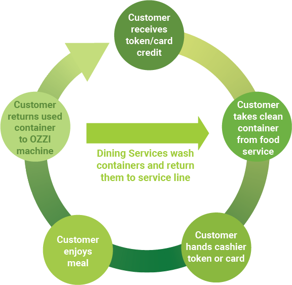

## About the Options

Now that you have seen how the system looks, here’s a quick explanation of the features you will be choosing between in the next questions.

We use short labels in the tables, but this page explains what each means and what each level represents.

Each program option you see will include the following:

### Deposit

**What it means:**  
A small **pay-up front amount (in USD)** charged **each time you take a meal to go** in a reusable container.

**Levels:**  
- **$5**, **$10**

### Return

**What it means:**  
Where you can drop off used containers to get your refund or exchange for a clean one.

**Levels:**  
- **Dining Halls** — Return bins only in dining halls.  
- **Halls and Dorms** — Return bins are in dining halls and residence halls/dorms.  
- **Campus-wide** — Return bins are available across campus.

### Wash Cycles

**What it means:**  
How many times a reusable container can be washed and reused before it needs replacement.

**Levels:**  
- **50**, **75**, **100** wash cycles

> Higher numbers mean more durable containers.

### Refund

**What it means:**  
What happens to your deposit after return or loss.

**Levels:**  
- **Refundable** — Full deposit refunded.  
- **Non-refundable** — Deposit not refunded.  
- **FreeLoss** — Full refund on return + 1 free replacement if you lose a container once.

**How to answer:**  
In each question, you’ll see two reusable container program options.  
Please select the one you would choose **if those were your only options**.  
If you wouldn’t choose either, select **Disposable Container (Option_3)**.

```r
sd_next()
```

We’ll now begin the choice tasks. On the next few pages we will show you two reusable container program options and a base option and we’ll ask you to choose the one you most prefer.

# Practice Question

Let’s try a quick example so you know what to expect.

Imagine your school is offering the following reusable container programs. If these were your only choices, which one would you select?

```r
practice_buttons_option <- c("option_1", "option_2", "option_3")

names(practice_buttons_option) <- c("
**Option 1**<br>
**Deposit**: 5<br>
**Return**: Dining_Halls<br>
**Wash_cycles**: 50<br>
**Refund**: Non_Refundable<br>
",
"
**Option 2**<br>
**Deposit**: 10<br>
**Return**: Campus_wide<br>
**Wash_cycles**: 100<br>
**Refund**: FreeLoss<br>
",
"**Option 3**<br>
**Disposable container**"
)

sd_question(
  type   = 'mc_buttons',
  id     = 'cbc_practice',
  label  = "For example, if these were the only program options, which would you choose?",
  option = practice_buttons_option
)
```

For example, if these were the only program options, which would you choose?

```r
sd_next()
```

Great work!

We will now show you 6 sets of choice questions starting on the next page.

Let’s get started.

```r
sd_next()
```

# Question 1

```r
sd_output("cbc_q1", type = "question")
```

```r
sd_next()
```

# Question 2

```r
sd_output("cbc_q2", type = "question")
```

```r
sd_next()
```

# Question 3

```r
sd_output("cbc_q3", type = "question")
```

```r
sd_next()
```

# Question 4

```r
sd_output("cbc_q4", type = "question")
```

```r
sd_next()
```

# Question 5

```r
sd_output("cbc_q5", type = "question")
```

```r
sd_next()
```

# Question 6

```r
sd_output("cbc_q6", type = "question")
```

```r
sd_next()
```

# Demographics Page

We’re almost done! We’d just like to ask just a few more questions about you which we will only use for analyzing our survey data.

```r
sd_question(
type = 'mc',
id = 'waste_importance',
label = "How important is reducing single-use waste when choosing dining options?",
option = c('1 Not at all'='1','2'='2','3'='3','4'='4','5 Very'='5')
)
```

How important is reducing single-use waste when choosing dining options?

1 Not at all

2

3

4

5 Very

```r
sd_question(
type = 'mc',
id = 'ozzi_used',
label = "Have you used the OZZI system before?",
option = c('Yes'='yes','No'='no')
)
```

Have you used the OZZI system before?

Yes

No

```r
sd_question(
type = 'mc',
id = 'ozzi_satisfaction',
label = "How satisfied were you with OZZI?",
option = c('1'='1','2'='2','3'='3','4'='4','5'='5')
)
```

How satisfied were you with OZZI?

1

2

3

4

5

```r
sd_question(
type = 'mc',
id = 'container_preference',
label = "Which to-go container do you prefer most?",
option = c('Plastic'='plastic','Compostable'='compostable','OZZI Reusable'='ozzi','Other'='other')
)
```

Which to-go container do you prefer most?

Plastic

Compostable

OZZI Reusable

Other

```r
sd_question(
type = 'mc',
id = 'hall_frequency',
label = "How often do you eat in an on-campus or residential dining hall?",
option = c('Daily'='daily','3–4/week'='3_4_week','1–2/week'='1_2_week','<1×week'='lt1_week','Never'='never')
)
```

How often do you eat in an on-campus or residential dining hall?

Daily

3–4/week

1–2/week

<1×week

Never

```r
sd_question(
type = 'mc',
id = 'year',
label = "Current year:",
option = c('Freshman'='freshman','Sophomore'='sophomore','Junior'='junior','Senior'='senior','Graduate'='grad','Other'='other')
)
```

Current year:

Freshman

Sophomore

Junior

Senior

Graduate

Other

```r
sd_question(
type = 'text',
id = 'school_name',
label = "What college or university do you attend?"
)
```

What college or university do you attend?

```r
sd_next()
```

# End Page

The survey is finished. Thank you for your feedback!

Your completion code is:

You may close the window now.

```r
sd_close()
```

# End Page

The survey is finished. You may close the window.

```r
sd_close()
```